# House Pricing Analysis

In this notebook I'm trying to do some Analysis on [house prices](https://www.kaggle.com/c/house-prices-advanced-regression-techniques) based on the features of each house and the relation between the price and the features

by answering the following questions:-

- What are the most features that affect the price ?
- What is the salling price dustribution ?
- What is the area distribution in sq feet ?
- How many cars can most of the houses hold ?
- What is the most common over all qualtiy and what is its percentage ?
- What is the most common over all condition and what is its percentage ?
- What are the top 5 common neighborhoods ?
- What are the top 5 expensive neighborhoods ?
- What is the most common selling type ?
- What is the most common sale condition ?
- What is the relation between the building year of a building and the selling price ?
- What is the destribution of the classification zones to the sale price and the area of the proerty ?
- What is the relation between the area and the price -What is the relation between the neighborhoods and the shape of the house?

```python
import pandas as pd
import numpy as np
import matplotlib.pyplot as plt
import seaborn as sns
%matplotlib inline
```

```python
house_df = pd.read_csv('train.csv')
house_df.head(5)
```

|  | Id | MSSubClass | MSZoning | LotFrontage | LotArea | Street | Alley | LotShape | LandContour | Utilities | ... | PoolArea | PoolQC | Fence | MiscFeature | MiscVal | MoSold | YrSold | SaleType | SaleCondition | SalePrice |
| --- | --- | --- | --- | --- | --- | --- | --- | --- | --- | --- | --- | --- | --- | --- | --- | --- | --- | --- | --- | --- | --- |
| 0 | 1 | 60 | RL | 65.0 | 8450 | Pave | NaN | Reg | Lvl | AllPub | ... | 0 | NaN | NaN | NaN | 0 | 2 | 2008 | WD | Normal | 208500 |
| 1 | 2 | 20 | RL | 80.0 | 9600 | Pave | NaN | Reg | Lvl | AllPub | ... | 0 | NaN | NaN | NaN | 0 | 5 | 2007 | WD | Normal | 181500 |
| 2 | 3 | 60 | RL | 68.0 | 11250 | Pave | NaN | IR1 | Lvl | AllPub | ... | 0 | NaN | NaN | NaN | 0 | 9 | 2008 | WD | Normal | 223500 |
| 3 | 4 | 70 | RL | 60.0 | 9550 | Pave | NaN | IR1 | Lvl | AllPub | ... | 0 | NaN | NaN | NaN | 0 | 2 | 2006 | WD | Abnorml | 140000 |
| 4 | 5 | 60 | RL | 84.0 | 14260 | Pave | NaN | IR1 | Lvl | AllPub | ... | 0 | NaN | NaN | NaN | 0 | 12 | 2008 | WD | Normal | 250000 |

5 rows × 81 columns

# Util Functions

some functions to help with the work

```python
def normalize_y_axis(data_series):
    n_points = house_df.shape[0]
    max_count = data_series.value_counts().max()
    max_prop = max_count / n_points

    # generate tick mark locations and names
    tick_props = np.arange(0, max_prop, 0.05)
    tick_names = ['{:0.2f}'.format(v) for v in tick_props]
    plt.yticks(tick_props * n_points, tick_names)
    plt.ylabel('proportion')
```

# Data Cleaning

First we will start by exploring the data and handling the null values

```python
house_df.info()
```

```
<class 'pandas.core.frame.DataFrame'>
RangeIndex: 1460 entries, 0 to 1459
Data columns (total 81 columns):
 #   Column         Non-Null Count  Dtype
---  ------         --------------  -----
 0   Id             1460 non-null   int64
 1   MSSubClass     1460 non-null   int64
 2   MSZoning       1460 non-null   object
 3   LotFrontage    1201 non-null   float64
 4   LotArea        1460 non-null   int64
 5   Street         1460 non-null   object
 6   Alley          91 non-null     object
 7   LotShape       1460 non-null   object
 8   LandContour    1460 non-null   object
 9   Utilities      1460 non-null   object
```

[output cut: 73 more lines]

Get correlation between the numerical fields and the price

```python
cols_corr_to_price = house_df.corr().abs()['SalePrice'].sort_values()
cols_corr_to_price
```

```
BsmtFinSF2       0.011378
BsmtHalfBath     0.016844
MiscVal          0.021190
Id               0.021917
LowQualFinSF     0.025606
YrSold           0.028923
3SsnPorch        0.044584
MoSold           0.046432
OverallCond      0.077856
MSSubClass       0.084284
PoolArea         0.092404
ScreenPorch      0.111447
EnclosedPorch    0.128578
KitchenAbvGr     0.135907
BedroomAbvGr     0.168213
BsmtUnfSF        0.214479
BsmtFullBath     0.227122
LotArea          0.263843
HalfBath         0.284108
OpenPorchSF      0.315856
2ndFlrSF         0.319334
WoodDeckSF       0.324413
LotFrontage      0.351799
BsmtFinSF1       0.386420
Fireplaces       0.466929
MasVnrArea       0.477493
GarageYrBlt      0.486362
YearRemodAdd     0.507101
YearBuilt        0.522897
TotRmsAbvGrd     0.533723
FullBath         0.560664
1stFlrSF         0.605852
TotalBsmtSF      0.613581
GarageArea       0.623431
GarageCars       0.640409
GrLivArea        0.708624
OverallQual      0.790982
SalePrice        1.000000
Name: SalePrice, dtype: float64
```

drop all the numerical columns with correlation less than 25%, note that `OverallCond` and `MSSubClass` are categorical values

```python
keys_to_drop = cols_corr_to_price[cols_corr_to_price < .25].keys().tolist()
cat_list = ['OverallCond','MSSubClass']
keys_to_drop = set(keys_to_drop)  - set(cat_list)
```

```python
house_df.drop(columns = list(keys_to_drop),inplace=True)
```

What are the most features that affect the price ?

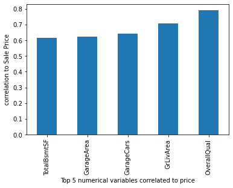

```python
cols_corr_to_price = house_df.corr().abs()['SalePrice'].sort_values()
corr = cols_corr_to_price[-6:-1]
corr.plot(kind='bar')
plt.xlabel('Top 5 numerical variables correlated to price')
plt.ylabel('correlation to Sale Price')
```

```python
nulls_series = house_df.columns[house_df.isna().any()].tolist()
print(house_df.isnull().sum().sort_values().to_string())
```

```
MSSubClass          0
Foundation          0
SaleCondition       0
BsmtFinSF1          0
TotalBsmtSF         0
Heating             0
HeatingQC           0
CentralAir          0
1stFlrSF            0
2ndFlrSF            0
GrLivArea           0
ExterCond           0
FullBath            0
KitchenQual         0
TotRmsAbvGrd        0
Functional          0
Fireplaces          0
GarageCars          0
GarageArea          0
PavedDrive          0
WoodDeckSF          0
OpenPorchSF         0
SaleType            0
HalfBath            0
ExterQual           0
SalePrice           0
LandSlope           0
LandContour         0
Neighborhood        0
Condition1          0
Condition2          0
BldgType            0
HouseStyle          0
OverallQual         0
OverallCond         0
LotConfig           0
YearBuilt           0
LotShape            0
RoofStyle           0
RoofMatl            0
```

[output cut: 11 more lines]

```
BsmtQual           37
BsmtCond           37
BsmtExposure       38
BsmtFinType2       38
GarageQual         81
GarageCond         81
GarageFinish       81
GarageYrBlt        81
GarageType         81
LotFrontage       259
FireplaceQu       690
Fence            1179
Alley            1369
MiscFeature      1406
PoolQC           1453
```

drop the most nullable columns `PoolQC`,`MiscFeature`,`Alley` and `Fence`

```python
house_df.drop(columns=['PoolQC','MiscFeature','Alley','Fence'],inplace=True)
```

drop the nullable row `Electrical`

```python
house_df.drop(house_df[house_df['Electrical'].isna()].index[0],inplace=True)
```

```python
print(house_df.isnull().sum().sort_values().to_string())
```

```
MSSubClass         0
SaleCondition      0
BsmtFinSF1         0
TotalBsmtSF        0
Heating            0
HeatingQC          0
CentralAir         0
Electrical         0
1stFlrSF           0
2ndFlrSF           0
GrLivArea          0
Foundation         0
FullBath           0
KitchenQual        0
TotRmsAbvGrd       0
Functional         0
Fireplaces         0
GarageCars         0
GarageArea         0
PavedDrive         0
WoodDeckSF         0
OpenPorchSF        0
SaleType           0
HalfBath           0
ExterCond          0
SalePrice          0
Condition1         0
LandSlope          0
Neighborhood       0
ExterQual          0
Condition2         0
BldgType           0
HouseStyle         0
OverallQual        0
OverallCond        0
YearBuilt          0
YearRemodAdd       0
RoofStyle          0
RoofMatl           0
LandContour        0
Exterior1st        0
LotShape           0
Exterior2nd        0
Street             0
LotArea            0
MSZoning           0
LotConfig          0
Utilities          0
MasVnrArea         8
MasVnrType         8
BsmtFinType1      37
BsmtCond          37
BsmtQual          37
BsmtFinType2      38
BsmtExposure      38
GarageType        81
GarageYrBlt       81
GarageFinish      81
GarageQual        81
GarageCond        81
LotFrontage      259
FireplaceQu      689
```

now let's do some investigation on Fireplaces we know that we have a column `Fireplaces` that represents the number of fireplaces in the house, we will try to find the number of houses with zero fireplace and compare that number with `FireplaceQu`

```python
print(len(house_df.groupby('Fireplaces').get_group(0)))
```

```
689
```

we find that the number of `0 Fireplaces` is the same as the number of `Nan` values in `FirePlaceQu` which means there are no null values in `FireplaceQu` now we will replace the `Nan` value to `NA` in `FireplaceQu`

```python
house_df.FireplaceQu.fillna('NA',inplace=True)
house_df.FireplaceQu.isnull().sum()
```

```
0
```

Now if we check the `Garage` attributes we will find that some of them have the same number of nulls `81` so we will asume that those units have no Garage and we can sure make sure by checking the number of `GarageArea == 0`, so lets replace the `nan` value with `NA`

```python
len(house_df.query('GarageArea == 0'))
```

```
81
```

```python
#so from above as we can see that the units with 0 of GarageArea = 81 so let's replace the null values with NA
house_df.fillna({'GarageCond':'NA','GarageQual':'NA','GarageFinish':'NA','GarageType':0,'GarageYrBlt':0},inplace=True)
print(house_df.isnull().sum().sort_values().to_string())
```

```
MSSubClass         0
TotalBsmtSF        0
Heating            0
HeatingQC          0
CentralAir         0
Electrical         0
1stFlrSF           0
2ndFlrSF           0
GrLivArea          0
FullBath           0
HalfBath           0
KitchenQual        0
TotRmsAbvGrd       0
BsmtFinSF1         0
Functional         0
FireplaceQu        0
GarageType         0
GarageYrBlt        0
GarageFinish       0
GarageCars         0
GarageArea         0
GarageQual         0
GarageCond         0
PavedDrive         0
WoodDeckSF         0
OpenPorchSF        0
SaleType           0
Fireplaces         0
SaleCondition      0
SalePrice          0
OverallQual        0
Utilities          0
LotConfig          0
LandSlope          0
Neighborhood       0
Condition1         0
Condition2         0
BldgType           0
HouseStyle         0
Street             0
OverallCond        0
YearBuilt          0
YearRemodAdd       0
RoofStyle          0
RoofMatl           0
Exterior1st        0
Exterior2nd        0
ExterQual          0
ExterCond          0
LotArea            0
Foundation         0
MSZoning           0
LandContour        0
LotShape           0
MasVnrType         8
MasVnrArea         8
BsmtQual          37
BsmtFinType1      37
BsmtCond          37
BsmtFinType2      38
BsmtExposure      38
LotFrontage      259
```

replace the nan values in `MasVnrType` with `NA` and `MasVnrArea` with `0`

```python
house_df.fillna({'MasVnrType':'NA','MasVnrArea':0},inplace=True)
```

Now let's replace the `Null` basements with `NA` values also

```python
house_df.fillna({'BsmtExposure':'NA','BsmtFinType2':'NA','BsmtFinType1':'NA','BsmtQual':'NA','BsmtCond':'NA'},inplace=True)
```

Finally we will drop the rows of the `null` `LotFrontage`

```python
house_df.drop(house_df[house_df['LotFrontage'].isna()].index,inplace=True)
```

# Data Exploration Phase

now we will start be exploring different variables and explore them using visualizations

### What is the salling price distrebution ?

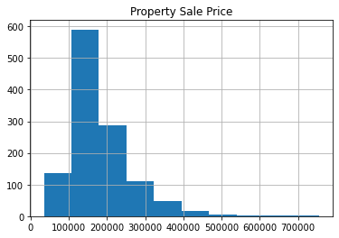

```python
house_df['SalePrice'].hist();
plt.title('Property Sale Price')
```

### What is the area distribution in sq feet ?

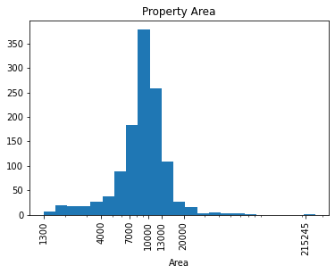

```python
x_bins =10 ** np.arange(np.log10(house_df.LotArea.min()),np.log10(house_df.LotArea.max())+.1,.1)
plt.hist(data = house_df,x='LotArea',bins=x_bins);
plt.xscale('log');
plt.title('Property Area')
plt.xlabel('Area')
tick_locs = [1300, 4000,7000, 10000, 13000,20000, 215245]
plt.xticks(tick_locs, tick_locs,rotation=90);
```

### How many cars can most of the houses hold ?

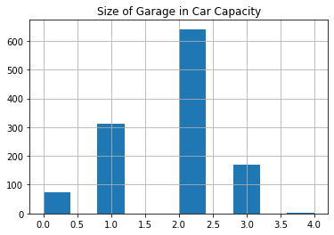

```python
house_df['GarageCars'].hist();
plt.title('Size of Garage in Car Capacity');
```

### What is the most common over all qualtiy and what is its percentage ?

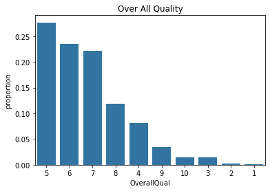

```python
color_p = sns.color_palette()[0]
sns.countplot(data = house_df, x = 'OverallQual',color = color_p,order = house_df['OverallQual'].value_counts().index)
plt.title('Over All Quality')
normalize_y_axis(house_df['OverallQual'])
```

### What is the most common overall condition and what is its percentage ?

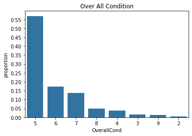

```python
color_p = sns.color_palette()[0]
sns.countplot(data = house_df, x = 'OverallCond',color = color_p,order = house_df['OverallCond'].value_counts().index)
plt.title('Over All Condition')
normalize_y_axis(house_df['OverallCond'])
```

### What is the most common selling type ?

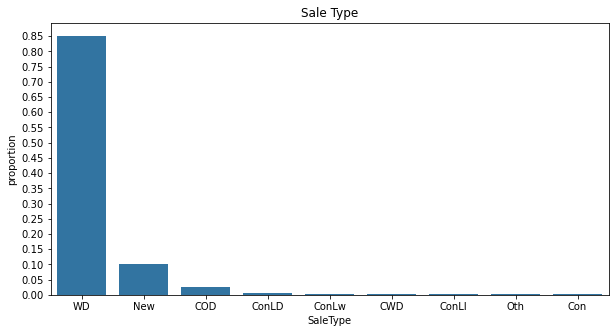

```python
plt.figure(figsize=(10,5))

color_p = sns.color_palette()[0]
sns.countplot(data = house_df, x = 'SaleType',color = color_p,order = house_df['SaleType'].value_counts().index)
plt.title('Sale Type')

# get proportion taken by most common group for derivation
# of tick marks
normalize_y_axis(house_df['SaleType'])
```

### What is the most common sale condition ?

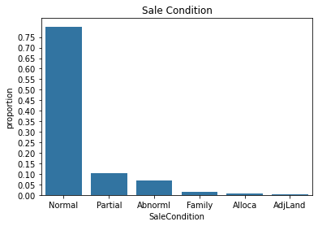

```python
color_p = sns.color_palette()[0]
sns.countplot(data = house_df, x = 'SaleCondition',color = color_p,order = house_df['SaleCondition'].value_counts().index)
plt.title('Sale Condition')
normalize_y_axis(house_df['SaleCondition'])
```

### What are the top 5 common neighborhoods ?

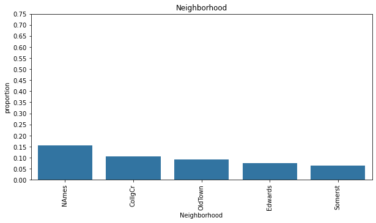

```python
plt.figure(figsize=(10,5))

#draw_bar_plot('Neighborhood','Neighborhood')
color_p = sns.color_palette()[0]
sns.countplot(data = house_df, x = 'Neighborhood',color = color_p, order = house_df['Neighborhood'].value_counts().index[:5])
plt.title('Neighborhood');
plt.xticks(rotation=90);
normalize_y_axis(house_df['SaleCondition'])
```

### What are the top 5 expensive neighborhoods ?

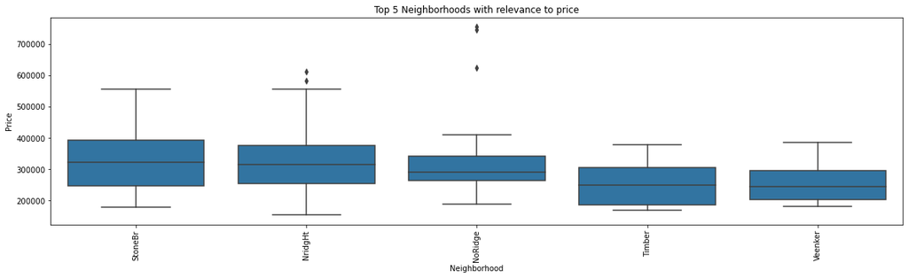

```python
color_p = sns.color_palette()[0]
plt.figure(figsize=(20,5))

sns.boxplot(data=house_df,x = 'Neighborhood',y = 'SalePrice',color = color_p,order = house_df.groupby('Neighborhood')['SalePrice'].median().sort_values(ascending=False).index[:5]);
plt.xticks(rotation=90);
plt.title('Top 5 Neighborhoods with relevance to price')
plt.ylabel('Price')
plt.xlabel('Neighborhood')
```

### What is the relation between the area and the price

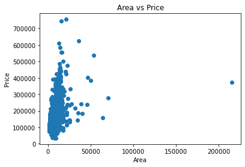

```python
plt.scatter(data=house_df,x = 'LotArea', y ='SalePrice');
plt.xlabel('Area');
plt.ylabel('Price');
plt.title('Area vs Price');
```

we can see that we have a very large area, we will check it out to see if it's an outlier

```python
largest_house = house_df[house_df['LotArea']==house_df['LotArea'].max()]
print(largest_house.FullBath)
print(largest_house.GarageCars)
```

```
313    2
Name: FullBath, dtype: int64
313    2
Name: GarageCars, dtype: int64
```

As we can see that the house with the largest area is probably an outlier, as house of this size will have more than 2 bathrooms and Garage of 2 cars capecity, so we will remove this house from our dataset

```python
house_df.drop(largest_house.index,inplace=True)
```

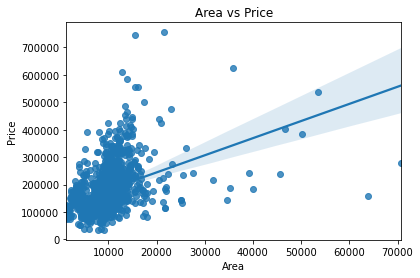

```python
sns.regplot(data=house_df,x = 'LotArea', y ='SalePrice');
plt.xlabel('Area');
plt.ylabel('Price');
plt.title('Area vs Price');
```

### What is the destribution of the classification zones to the sale price and the area of the proerty ?

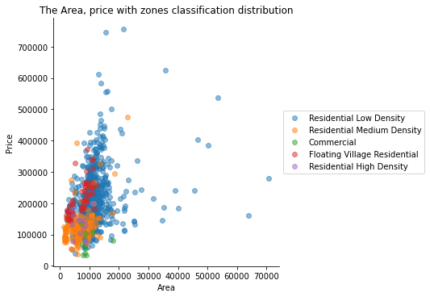

```python
g = sns.FacetGrid(data = house_df, hue = 'MSZoning', size = 5)
g.map(plt.scatter, 'LotArea', 'SalePrice',alpha=.5)
plt.xlabel('Area')
plt.title('The Area, price with zones classification distribution');
plt.ylabel('Price')
plt.legend(labels=['Residential Low Density','Residential Medium Density','Commercial','Floating Village Residential','Residential High Density'],loc='center left',bbox_to_anchor=(1, 0.5))
```

### What is the relation between the building year of a building and the selling price ?

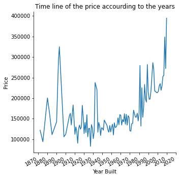

```python
plt.figure(figsize=(10,8))
g = sns.relplot(x="YearBuilt", y="SalePrice", ci=None,kind="line", data=house_df);
x_ticks = np.arange(1870,2030,10).tolist();
g.fig.autofmt_xdate();
plt.xticks(x_ticks,x_ticks);
plt.title('Time line of the price accourding to the years');
plt.ylabel('Price')
plt.xlabel('Year Built')
```

### What is the relation between the neighborhoods and the shape of the house?

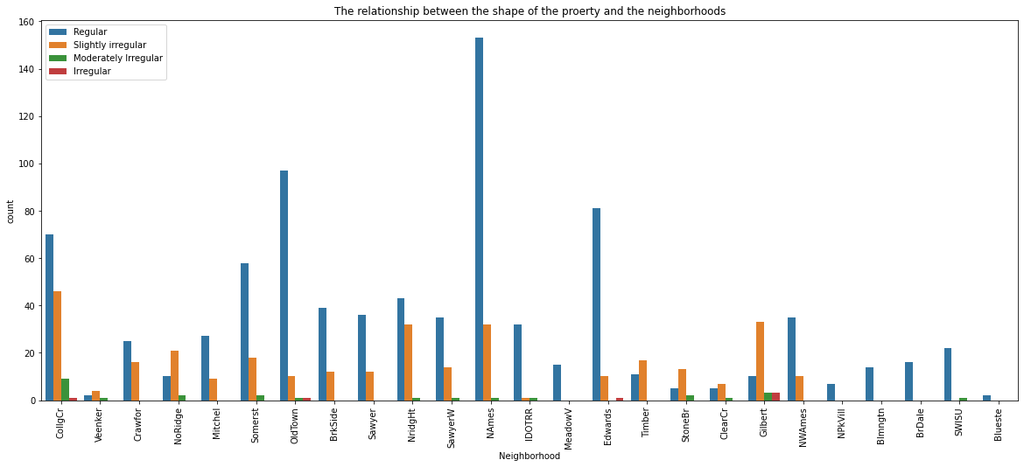

```python
plt.figure(figsize=(20,8))

sns.countplot(data= house_df,x = 'Neighborhood', hue = 'LotShape')
plt.xticks(rotation=90);
plt.legend(labels = ['Regular','Slightly irregular','Moderately Irregular', 'Irregular']);
plt.title('The relationship between the shape of the proerty and the neighborhoods')
```